# Activity: Bird Species

Jingyu Wang

03.08.2021

# Set Up

```r
# Load `tidyverse` and `dcData` packages
library(tidyverse)
library(dcData)
library(esquisse)



# `OrdwayBirds` data intake (from the `dcData` package)
data(OrdwayBirds, package = "dcData")



# Use R commands to inspect the data set a few different ways
view(OrdwayBirds)
help(OrdwayBirds)
```

# Activity

When you’re finished with this activity, you will have a graph that shows what time of year various species appear at the Katherine Ordway Natural History Study Area in Inver Grove Heights, MN.

### Step 0

Before we begin, the book gives us some instructions to select a few key variables and clean up the date formatting. Use the commands given in the book, but be sure to study the functions used so you know what is happening. In this case, we select `SpeciesName`, `Month`, and `Day`. Then a `mutate()` command converts each variable to character, and then converts the resulting “character string” to a number.

```r
# Get the data table & clean up dates (see Data Computing eBook)
OrdwayBirds <-
  OrdwayBirds %>%
  select( SpeciesName, Month, Day ) %>%
  mutate( Month = as.numeric(as.character(Month)),
          Day = as.numeric(as.character(Day)))

# Inspect resulting data
OrdwayBirds
```

|  | SpeciesName | Month | Day |
| --- | --- | --- | --- |
| 3 | Song Sparrow | 7 | 16 |
| 4 |  | NA | NA |
| 5 | Song Sparrow | 7 | 16 |
| 6 | Field Sparrow | 7 | 16 |
| 7 | Field Sparrow | 7 | 16 |
| 8 | Song Sparrow | 7 | 16 |
| 9 | Field Sparrow | 7 | 16 |
| 10 | Song Sparrow | 7 | 16 |
| 11 | Field Sparrow | 7 | 16 |
| 12 | House Sparrow | 7 | 16 |

[output cut: 990 more lines]

```r
NA
```

### Step 1

```r
# unique species in original data (including mis-spellings)
nrow(OrdwayBirds)
```

```
[1] 15829
```

```r
n_distinct(OrdwayBirds)
```

```
[1] 15825
```

```r
# unique species in the clean list
view(OrdwaySpeciesNames)
n_distinct(OrdwaySpeciesNames)
```

```
[1] 251
```

### Step 2

```r
# inspect OrdwaySpeciesNames
view(OrdwaySpeciesNames)
help(OrdwaySpeciesNames)
nrow(OrdwaySpeciesNames)
```

```
[1] 265
```

```r
# inner join
Corrected <-
  OrdwayBirds %>%
  inner_join( OrdwaySpeciesNames ) %>%
  select( Species = SpeciesNameCleaned, Month, Day ) %>%
  na.omit()  # cleaned up the missing ones
# inspect the data after the join
Corrected
```

|  | Species | Month | Day |
| --- | --- | --- | --- |
| 1 | Song Sparrow | 7 | 16 |
| 3 | Song Sparrow | 7 | 16 |
| 4 | Field Sparrow | 7 | 16 |
| 5 | Field Sparrow | 7 | 16 |
| 6 | Field Sparrow | 7 | 16 |
| 7 | Field Sparrow | 7 | 16 |
| 8 | Song Sparrow | 7 | 16 |
| 9 | Field Sparrow | 7 | 16 |
| 10 | Field Sparrow | 7 | 16 |
| 11 | Song Sparrow | 7 | 16 |

[output cut: 990 more lines]

```r
NA
```

### Step 3

We want to identify the top 5-6 bird species sighted at the Katherine Ordway Natural History Study Area.

```r
# count sightings by species in descending order
RightCount <-
  Corrected %>%
  group_by(Species) %>%
  summarize(count=n()) %>%
  arrange(desc(count))
RightCount
```

| Species | count |
| --- | --- |
| Slate-colored Junco | 2732 |
| Tree Swallow | 1537 |
| Black-capped Chickadee | 1327 |
| American Goldfinch | 1204 |
| Field Sparrow | 1164 |
| Lincoln's Sparrow | 790 |
| Robin | 608 |
| Catbird | 554 |
| Song Sparrow | 512 |
| House Wren | 460 |

[output cut: 98 more lines]

```r
# a hint in the eBook recommends displaying the top 10 species to choose our threshold
ToptenSpecies <-
  RightCount %>%
  top_n(10)
ToptenSpecies
```

| Species | count |
| --- | --- |
| Slate-colored Junco | 2732 |
| Tree Swallow | 1537 |
| Black-capped Chickadee | 1327 |
| American Goldfinch | 1204 |
| Field Sparrow | 1164 |
| Lincoln's Sparrow | 790 |
| Robin | 608 |
| Catbird | 554 |
| Song Sparrow | 512 |
| House Wren | 460 |

```r
Top10Birds <-
  RightCount %>%
  head(n = 10) %>%
  .$Species
Top10Birds
```

```
 [1] "Slate-colored Junco"    "Tree Swallow"           "Black-capped Chickadee"
 [4] "American Goldfinch"     "Field Sparrow"          "Lincoln's Sparrow"
 [7] "Robin"                  "Catbird"                "Song Sparrow"
[10] "House Wren"
```

```r
# define a sightings threshold; produce a table with only birds belonging to major species
Majors <-
  Corrected %>%
  filter(Species %in% Top10Birds)
Majors
```

| Species | Month | Day |
| --- | --- | --- |
| Song Sparrow | 7 | 16 |
| Song Sparrow | 7 | 16 |
| Field Sparrow | 7 | 16 |
| Field Sparrow | 7 | 16 |
| Field Sparrow | 7 | 16 |
| Field Sparrow | 7 | 16 |
| Song Sparrow | 7 | 16 |
| Field Sparrow | 7 | 16 |
| Field Sparrow | 7 | 16 |
| Song Sparrow | 7 | 16 |

[output cut: 990 more lines]

### Step 4

We now want to produce a month-by-month count for each of the major species, and then construct a chart to tell the story of what time of year the various species appear.

```r
# prepare glyph-ready data table called `ByMonth`
ByMonth <-
  Majors %>%
  group_by(Species, Month) %>%
  summarise(count = n()) %>%
  arrange(Month)
ByMonth
```

| Species | Month | count |
| --- | --- | --- |
| American Goldfinch | 1 | 10 |
| Black-capped Chickadee | 1 | 82 |
| Slate-colored Junco | 1 | 113 |
| Tree Swallow | 1 | 258 |
| American Goldfinch | 10 | 364 |
| Black-capped Chickadee | 10 | 193 |
| Catbird | 10 | 3 |
| Field Sparrow | 10 | 138 |
| Lincoln's Sparrow | 10 | 316 |
| Robin | 10 | 26 |

[output cut: 81 more lines]

```r
NA
```

Now, using `barGraphHelper()` in the console, we can configure a reasonable graph and choose “show expression” to get `ggplot2` that can be embedded in our report.

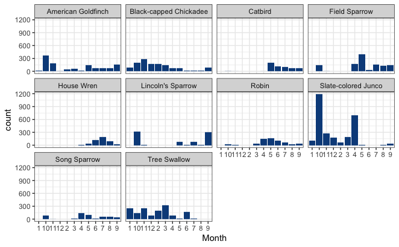

```r
# ggplot command
ggplot(ByMonth) +
 aes(x = Month, weight = count) +
 geom_bar(fill = "#0c4c8a") +
 theme_bw() +
 facet_wrap(vars(Species))
```

According to the graph, we can answer the questions posed:

##### 1. Which species are present year-round?

- The American Goldfinch and Black-capped chickadee.

##### 3. What is the peak month for each major species? (bullet list)

- American Goldfinch: October
- Black-capped Chickadee: November
- Catbird: May
- Field Sparrow: May
- House Wren: July
- Lincoln’s Sparrow: October
- Robin: May
- State-colored Junco: Octorber
- Song Sparrow: April
- Tree Swallow: March

##### 4. Which major species are seen in good numbers for at least 6 months of the year?

- They are American Goldfinch, Black-capped Chickadee, State-colored Junco, and Tree Swallow.